# Simple Maize Model 🌽 📈

### Implement the Maize Model in R

In this exercise, we will be implementing a simple maize model as presented in Wallach et al. (2014), *Working with Dynamic Crop Models*. Tables and figures presented in this document are from the Wallach et al. text.

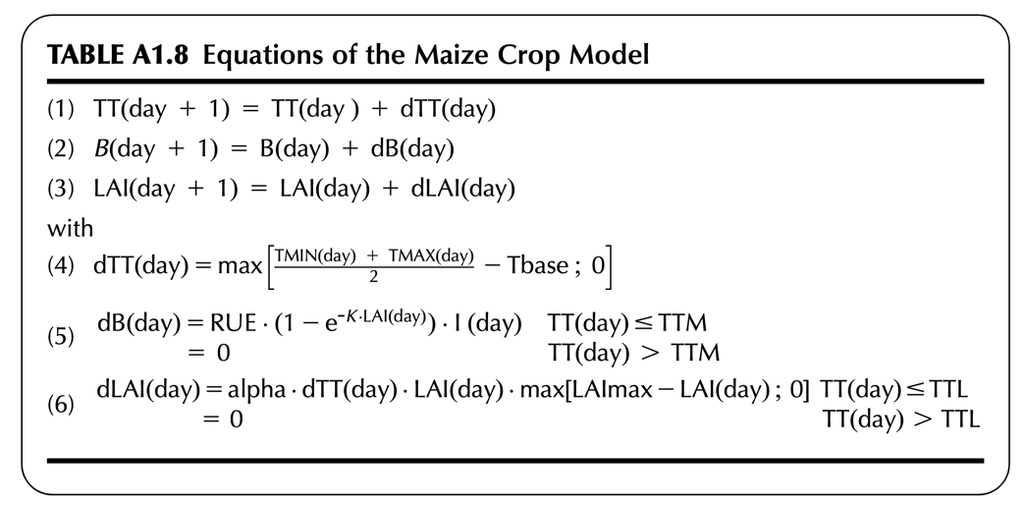

**Load packages and explanatory variable observations to your workspace.**  
It’s always a good idea to inspect and plot your explanatory variables.

```r
library(tidyverse)
weather <- read_csv("data/weather_observations.csv")
head(weather)
```

```
## # A tibble: 6 x 8
##   idsite GPSlatitude GPSlongitude  year   day     I  Tmax  Tmin
##    <dbl>       <dbl>        <dbl> <dbl> <dbl> <dbl> <dbl> <dbl>
## 1     92          54           23  2010     1   1.5  -5    -7.7
## 2     92          54           23  2010     2   1.2  -6.4 -11.4
## 3     92          54           23  2010     3   2.3 -12.5 -17.2
## 4     92          54           23  2010     4   1.5  -7.8 -16
## 5     92          54           23  2010     5   1.2  -8   -12.9
## 6     92          54           23  2010     6   1.1  -9.8 -16.1
```

**Define parameters**

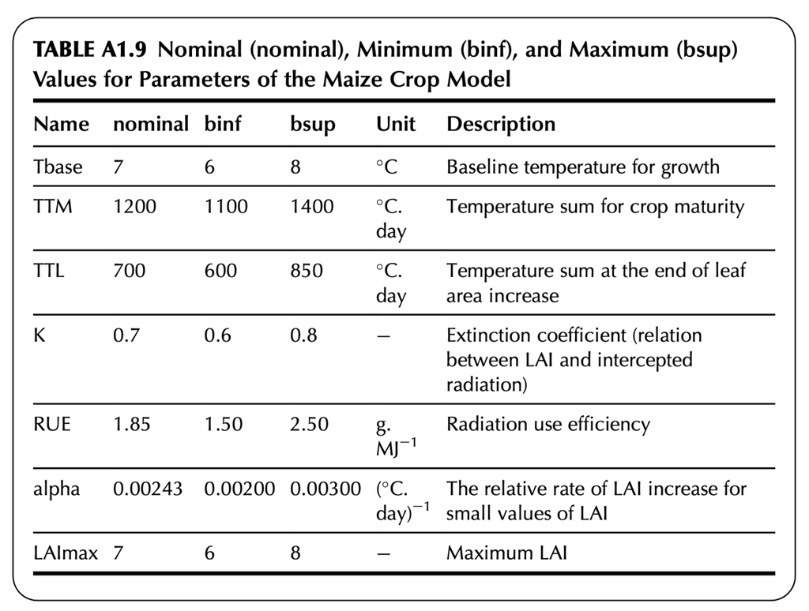

```r
# Baseline temperature for growth [deg. C]
Tb <- 7
# Temperature sum for crop maturity [deg.C/day]
TTM <- 1200
# Temperature sum at the end of leaf area increase [deg.C/day]
TTL <- 700
# Extinction coefficient [--]
K <- 0.7
# Radiation use efficiency [g/MJ]
RUE <- 1.85
# The relative rate of LAI increase for small values of LAI [deg.C/day]
a <- 0.00243
# Maximum LAI [m3/m3]
LAIm <- 7
```

**Initialize state variables**  
When you initialize a variable, you are creating an empty vector or object that you can populate with values during the simulation. To create this vector, we need to know how long it should be. The vector length will equal the number of timesteps in our simulation. In this case the number of timesteps = number of days in our explanatory variable dataset (i.e., `weather`).

```r
ndays <- nrow(weather)
# Thermal time age of the crop on day t [deg.C/day]
TT <- rep(NA, ndays)
# Leaf area index (area of leaves per unit ground area) [m3/m3]
LAI <- rep(NA, ndays)
# Biomass of crop per square meter of ground area [g/m2]
B <- rep(NA, ndays)
```

We also want to assign values to the first timestep in each of these state variables. By doing this, we’re providing a starting point to the models. Sometimes the starting point is 0, but it’s important to always specify.

```r
TT[1] <- 0
LAI[1] <- 0.1
B[1] <- 1
```

**Run the simulation**  
Now we can run the simulation! To simulate our state variable dynamics, calculate their rates of change. We will use a *for loop* to run the model for each each timestep. Replace the `***` (shown below) with code needed to execute each step.

```r
for (day in ***) {
  # Calculate rates of change
  ## dTT:
  dTT <- ***
  ## dB:
  if(TT[day] <= TTM) {dB <- ***}
  else {dB <- ***}
  ## dLAI:
  if (TT[day] <= TTL) {dLAI <- ***}
  else {dLAI <- ***}

  # Update state variables
  TT[day + 1] <- ***
  LAI[day + 1] <- ***
  B[day + 1] <- ***
}
```

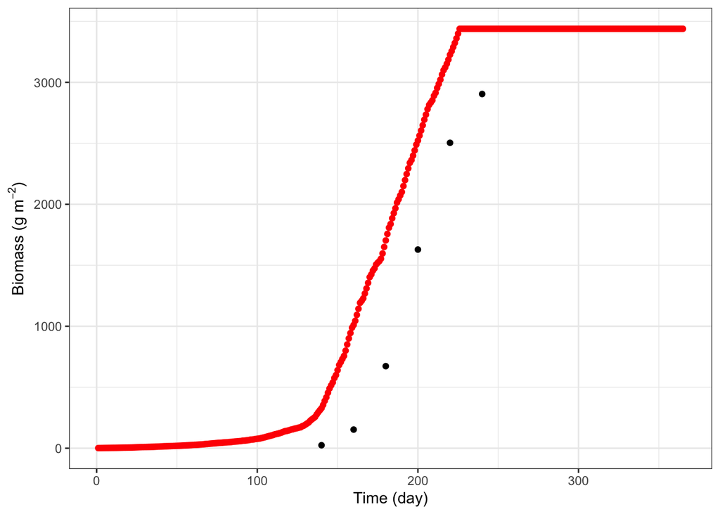

```r
outputs <- data.frame(day = weather$day, TT, LAI, B)
observations <- read_csv("data/state_variable_observations.csv")

ggplot() +
  geom_point(data = outputs,
             aes(x = day, y = B),
             color = "red") +
  geom_point(data = observations,
             aes(x = day, y = Bobs)) +
  theme_bw() +
  labs(x = "Time (day)",
       y = expression("Biomass (g "*m^{-2}*")"))
```

### Additional reference material

**Simulation workflow**

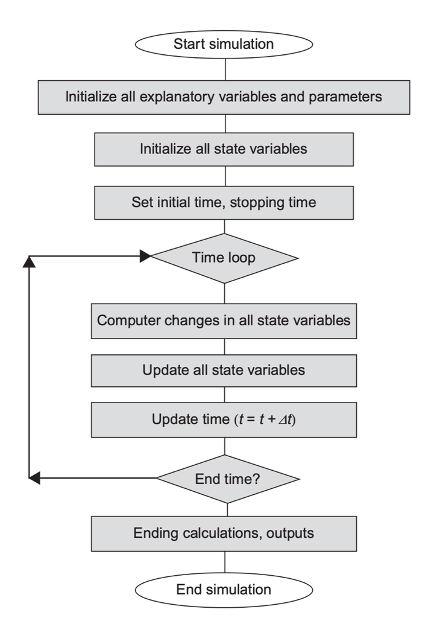

**Forrester diagram**

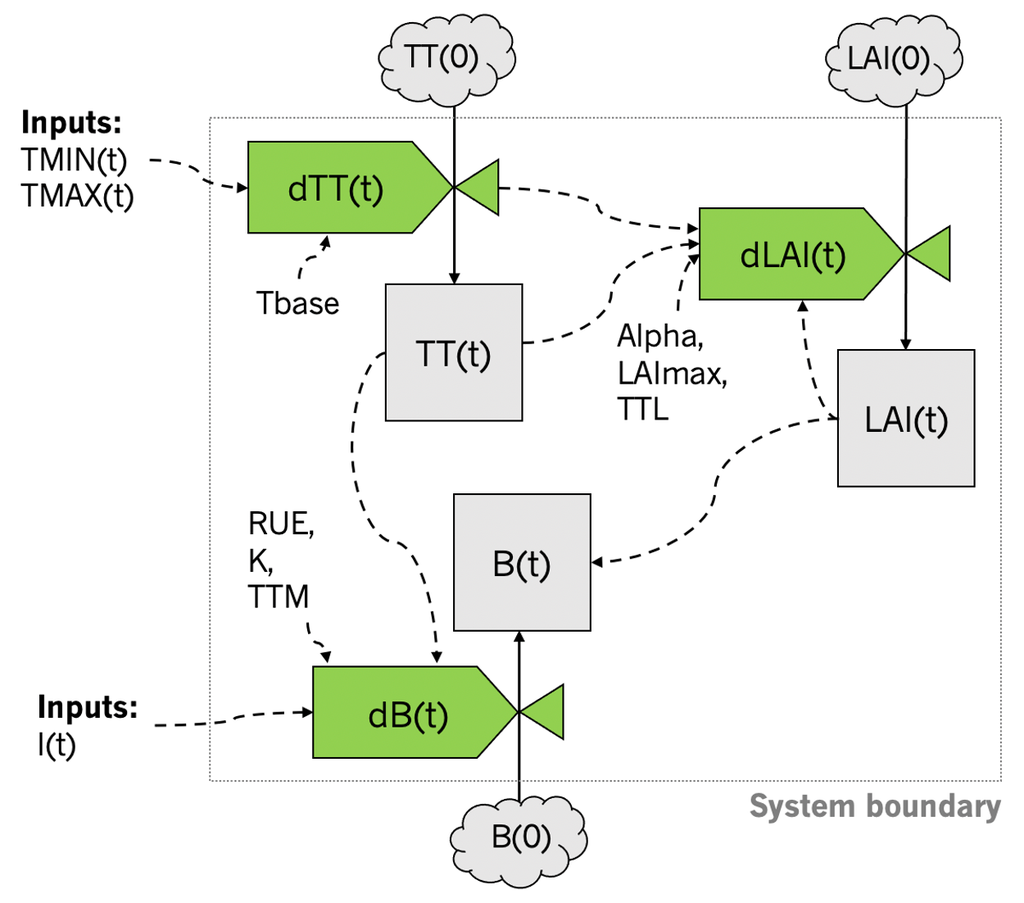